# Cartographie des laboratoires d’analyse médicale en Ile de France

6 novembre 2023

**J’ai traité les données d’abord par ZAE et ensuite par commune.**

- **Traitement par ZAE :**

La carte suivante présente la répartition spatiale des laboratoires d’analyse médicale en Ile de France projetés sur les contours des départements et des ZAE à l’intérieur de ces départements. **Les zones d’enquête séléctionnées sont surlignées en vert (UP = “up_95370”, “up_95371”, “up_77182”, “up_93066”)**.

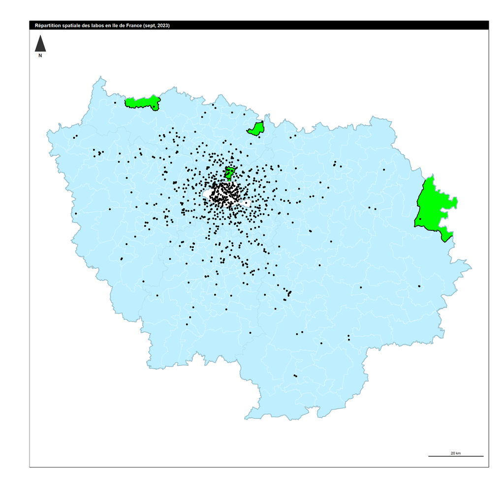

Le nombre de laboratoires d’analyse médicale par ZAE est présenté dans le tableau suivant :

Nombre de la boratoires d’analyse médicale par ZAE

| Nombre de labos | Nombre de ZAE | Pourcentage |
| --- | --- | --- |
| 0 | 134 | 30.8% |
| 1 | 142 | 32.6% |
| 2 | 85 | 19.5% |
| 3 | 31 | 7.1% |
| 4 | 18 | 4.1% |
| 5 | 14 | 3.2% |
| 6 | 4 | 0.9% |
| 7 | 2 | 0.5% |
| 8 | 4 | 0.9% |
| 11 | 1 | 0.2% |

Pour avoir une idée de la distance entre le centroïde d’une ZAE et les laboratoires d’analyse médicale, j’ai procédé de la façon suivante :

- Calcul du nombre de laboratoires par ZAE (nlabo)
- Identification des ZAE sans laoratoires (nlabo=0)
- Pour les ZAE sans laboratoires, recherche du laboratoire le plus proche à vol d’oiseau du centroïde de la ZAE et calcul de la distance euclidienne.

Les ZAE sans laboratoires d’analyse médicale sont représentées en rouge dans la carte suivante :

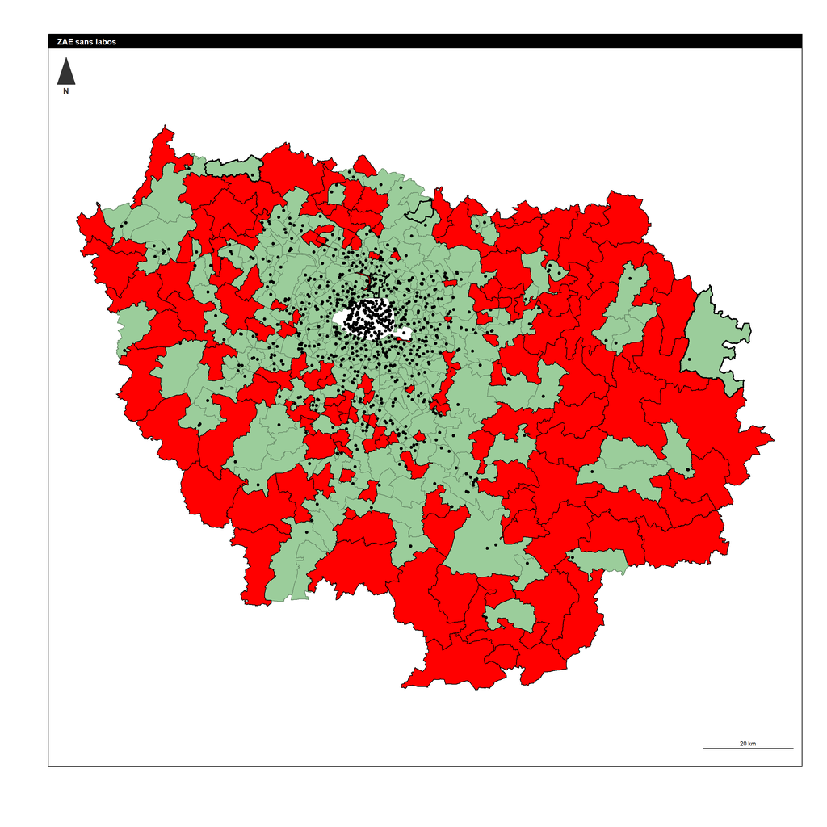

La distance en mètres entre le centroïde des ZAE (sans labos) et le laboratoire le plus proche est représentée ci-dessous :

```
##    Min. 1st Qu.  Median    Mean 3rd Qu.    Max.
##   326.2  2165.0  3927.2  4794.0  6702.0 15840.8
```

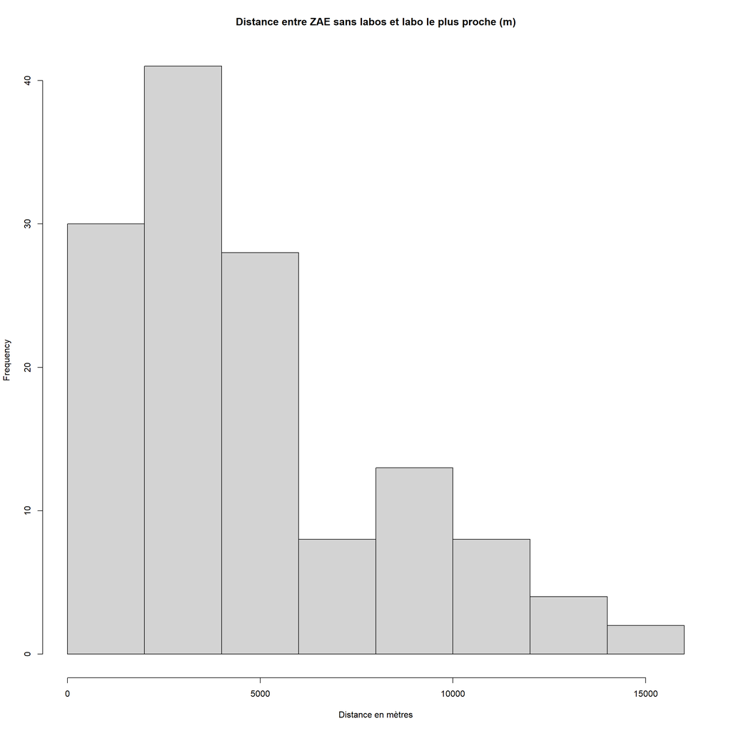

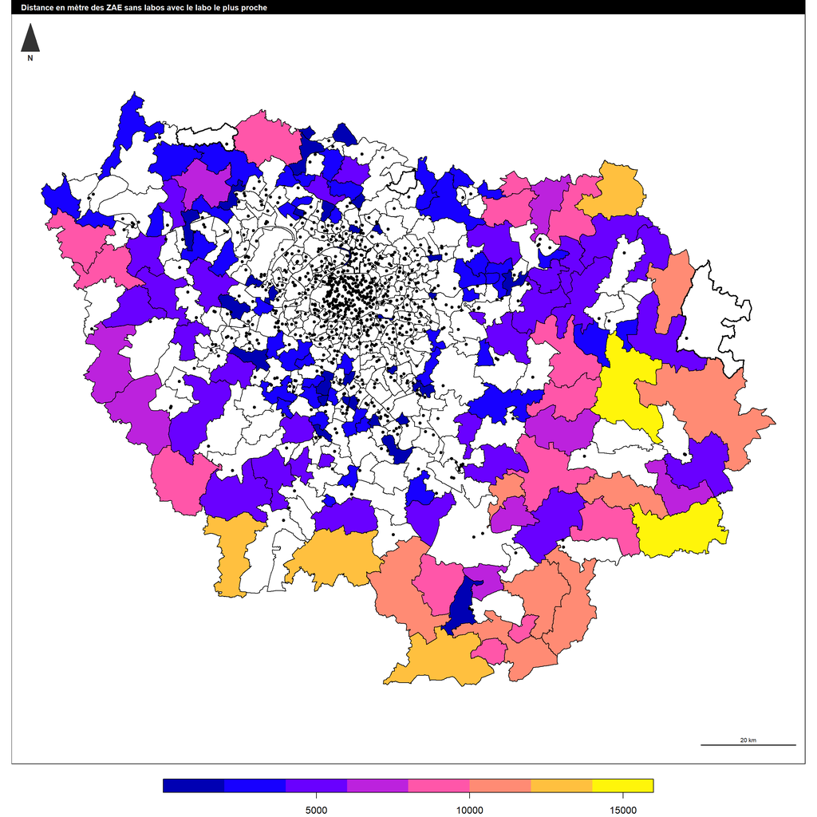

- **Traitement par commune :**

Le nombre de laboratoires d’analyse médicale par commune est présenté ainsi que la distance entre le centroïde des communes (sans labos) et le laboratoire le plus proche.

Le nombre de laboratoires d’analyse médicale par commune est présenté dans le tableau suivant :

Nombre de la boratoires d’analyse médicale par commune

[output not shown]

La distance en mètres entre le centroïde des communes (sans labos) et le laboratoire le plus proche est représentée ci-dessous d’abord pour l’ensemble des communes ensuite pour **les communes des zones d’enquête sélectionnées :**

```
##    Min. 1st Qu.  Median    Mean 3rd Qu.    Max.
##   326.2  3049.5  5291.6  6090.2  8197.7 20209.8
```

```
##    Min. 1st Qu.  Median    Mean 3rd Qu.    Max.
##    2263    3799    6248    6907   10515   14117
```

[figure not shown]

[figure not shown]

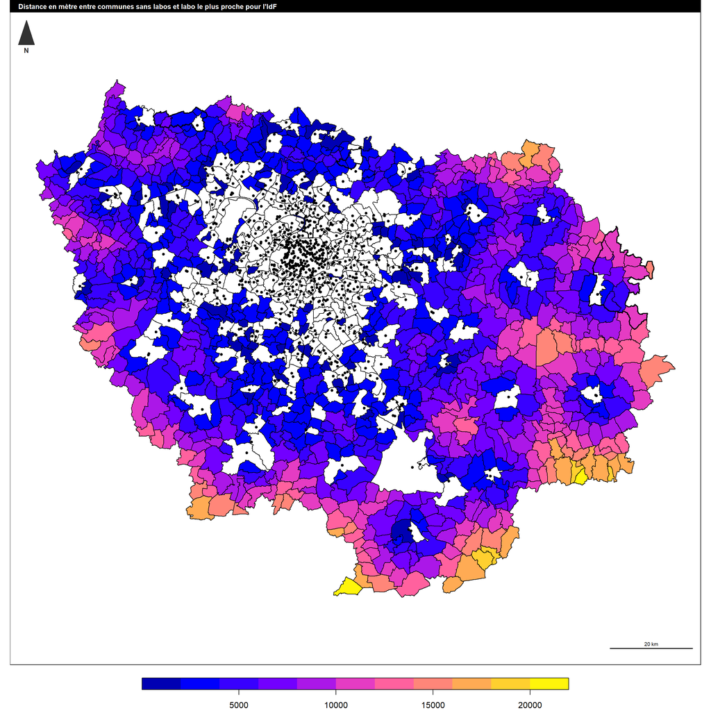

Le tableau ci-dessous présente les pricipaux laboratoires d’analyse médicale en Ile de France :

Pricipaux laboratoires d’analyse médicale présents dans l’extraction Finess des établissements sanitaires et socials géolocalisés en Ile de France au 04/09/2023

| Principaux laboratoires d’analyse médicale | Nombre de labos | Pourcentage |
| --- | --- | --- |
| Autres | 574 | 72.1% |
| Cerballiance | 151 | 19.0% |
| Eurofins | 9 | 1.1% |
| Synlab | 8 | 1.0% |
| Unilabs | 54 | 6.8% |

La carte ci-dessous présente les principaux réseaux de laboratoire en Ile de France. La modalité “Autres” regroupe tous les laboratoires autres que les principaux réseaux.

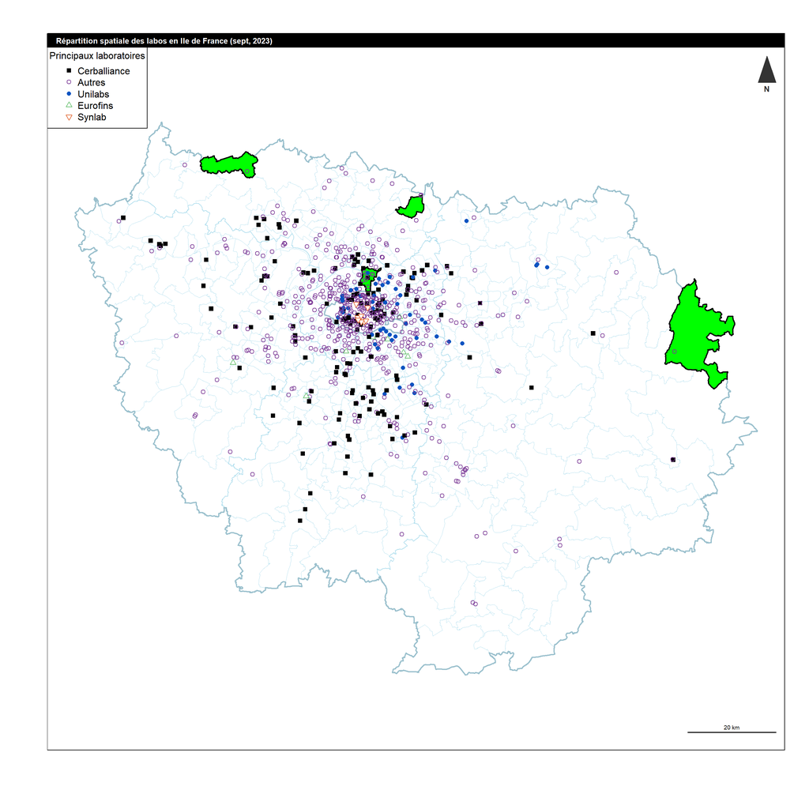

La carte ci-dessous présente les principaux réseaux de laboratoire en Ile de France. La modalité “Autres” a été exclue pour plus de lisibilité.

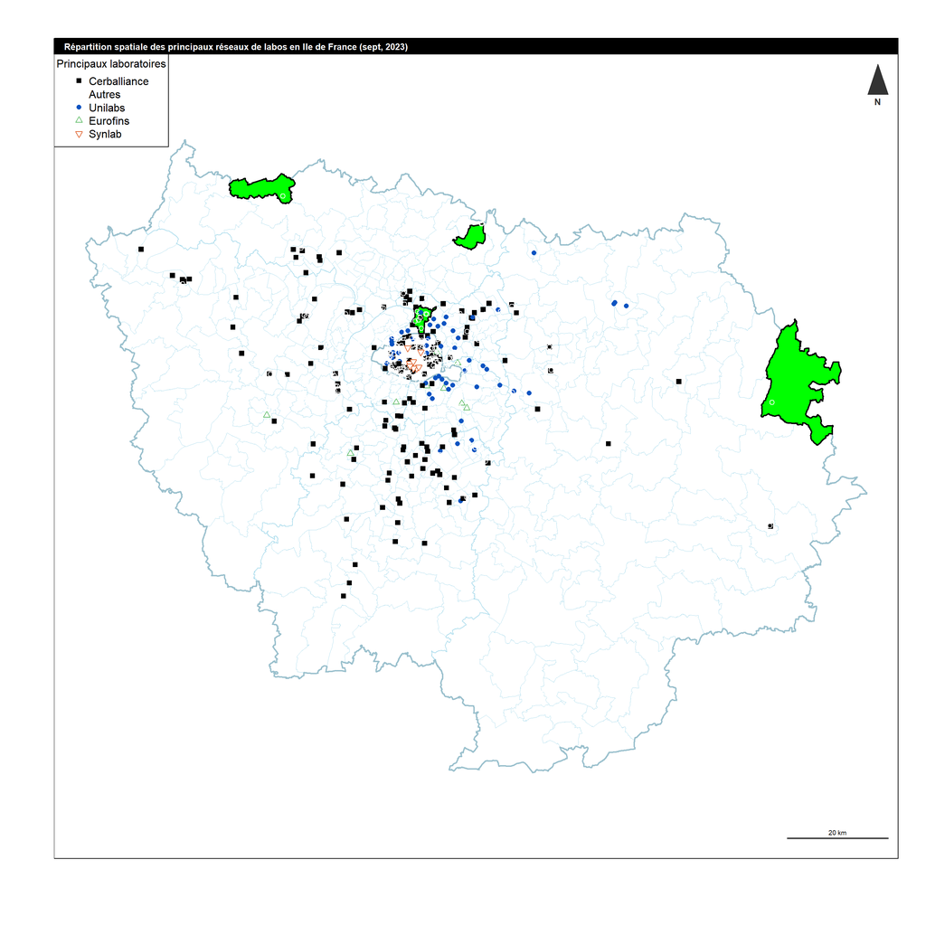

La répartition par département d’Ile de France des principaux laboratoires d’analyse médicale est présentée dans le tableau suivant :

Nombre de laboratoires d’analyse médicale par département

| dept | Cerballiance | Unilabs | Eurofins | Synlab | Autres | TOTAL |
| --- | --- | --- | --- | --- | --- | --- |
| 75 | 34 | 10 | 1 | 8 | 115 | 168 |
| 77 | 9 | 6 | 0 | 0 | 56 | 71 |
| 78 | 25 | 0 | 1 | 0 | 80 | 106 |
| 91 | 40 | 5 | 1 | 0 | 38 | 84 |
| 92 | 5 | 4 | 1 | 0 | 94 | 104 |
| 93 | 19 | 13 | 0 | 0 | 61 | 93 |
| 94 | 7 | 16 | 5 | 0 | 67 | 95 |
| 95 | 12 | 0 | 0 | 0 | 63 | 75 |
| TOTAL | 151 | 54 | 9 | 8 | 574 | 796 |